# Titanic Survival

## Data Exploration

```r
library(tidyverse)
library(RColorBrewer)
```

**Data Basics**  
How does the data look in the original file.

```r
train <- read.csv("./Data/train.csv")
summary(train)
```

```
  PassengerId       Survived          Pclass                                         Name         Sex
 Min.   :  1.0   Min.   :0.0000   Min.   :1.000   Abbing, Mr. Anthony                  :  1   female:314
 1st Qu.:223.5   1st Qu.:0.0000   1st Qu.:2.000   Abbott, Mr. Rossmore Edward          :  1   male  :577
 Median :446.0   Median :0.0000   Median :3.000   Abbott, Mrs. Stanton (Rosa Hunt)     :  1
 Mean   :446.0   Mean   :0.3838   Mean   :2.309   Abelson, Mr. Samuel                  :  1
 3rd Qu.:668.5   3rd Qu.:1.0000   3rd Qu.:3.000   Abelson, Mrs. Samuel (Hannah Wizosky):  1
 Max.   :891.0   Max.   :1.0000   Max.   :3.000   Adahl, Mr. Mauritz Nils Martin       :  1
                                                  (Other)                              :885
      Age            SibSp           Parch             Ticket         Fare                Cabin     Embarked
 Min.   : 0.42   Min.   :0.000   Min.   :0.0000   1601    :  7   Min.   :  0.00              :687    :  2
 1st Qu.:20.12   1st Qu.:0.000   1st Qu.:0.0000   347082  :  7   1st Qu.:  7.91   B96 B98    :  4   C:168
 Median :28.00   Median :0.000   Median :0.0000   CA. 2343:  7   Median : 14.45   C23 C25 C27:  4   Q: 77
 Mean   :29.70   Mean   :0.523   Mean   :0.3816   3101295 :  6   Mean   : 32.20   G6         :  4   S:644
 3rd Qu.:38.00   3rd Qu.:1.000   3rd Qu.:0.0000   347088  :  6   3rd Qu.: 31.00   C22 C26    :  3
 Max.   :80.00   Max.   :8.000   Max.   :6.0000   CA 2144 :  6   Max.   :512.33   D          :  3
 NA's   :177                                      (Other) :852                    (Other)    :186
```

```r
str(train)
```

```
'data.frame':   891 obs. of  12 variables:
 $ PassengerId: int  1 2 3 4 5 6 7 8 9 10 ...
 $ Survived   : int  0 1 1 1 0 0 0 0 1 1 ...
 $ Pclass     : int  3 1 3 1 3 3 1 3 3 2 ...
 $ Name       : Factor w/ 891 levels "Abbing, Mr. Anthony",..: 109 191 358 277 16 559 520 629 417 581 ...
 $ Sex        : Factor w/ 2 levels "female","male": 2 1 1 1 2 2 2 2 1 1 ...
 $ Age        : num  22 38 26 35 35 NA 54 2 27 14 ...
 $ SibSp      : int  1 1 0 1 0 0 0 3 0 1 ...
 $ Parch      : int  0 0 0 0 0 0 0 1 2 0 ...
 $ Ticket     : Factor w/ 681 levels "110152","110413",..: 524 597 670 50 473 276 86 396 345 133 ...
 $ Fare       : num  7.25 71.28 7.92 53.1 8.05 ...
 $ Cabin      : Factor w/ 148 levels "","A10","A14",..: 1 83 1 57 1 1 131 1 1 1 ...
 $ Embarked   : Factor w/ 4 levels "","C","Q","S": 4 2 4 4 4 3 4 4 4 2 ...
```

```r
train$Survived <- as.factor(train$Survived)
train$Pclass <- as.factor(train$Pclass)
```

**Passenger Id**  
The Passenger Id field only contains unique values as no duplicates were found.

```r
train %>%
  group_by(PassengerId) %>%
  summarise(total = n()) %>%
  filter(total > 1)
```

| PassengerId | total |
| --- | --- |

**Passengers by Class**  
As expected most passengers on the Titanic travelled third class.

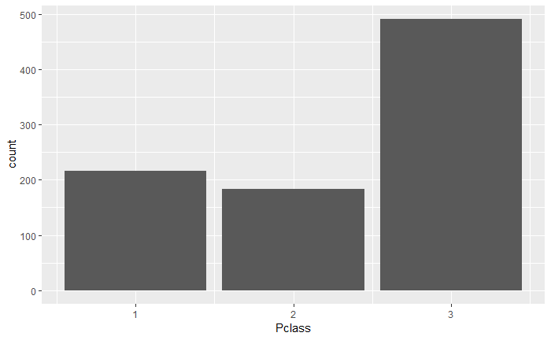

```r
train %>%
  ggplot() +
  geom_bar(mapping = aes(x = Pclass))
```

**Survival by Class**  
As a proportion of passengers travelling, those in first class were more likely to survive than those travelling in third class.

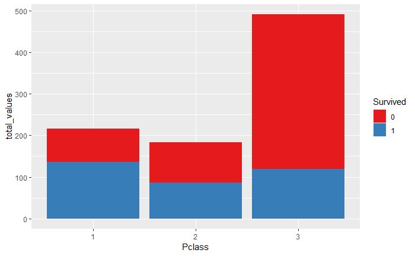

**Gender of Passengers**  
More men travelled on the Titanic than women.

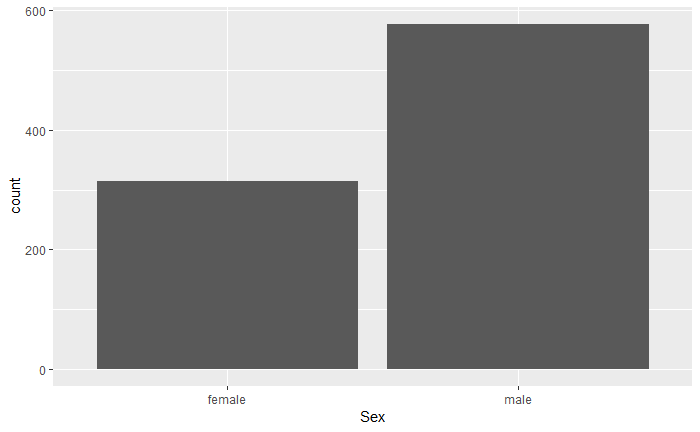

**Gender and Survival**  
Chivalry played its part as men were disproportinately more likely to die. Even though more men travelled on the Titanic on it’s fateful voyage less men than women, in total, survived.

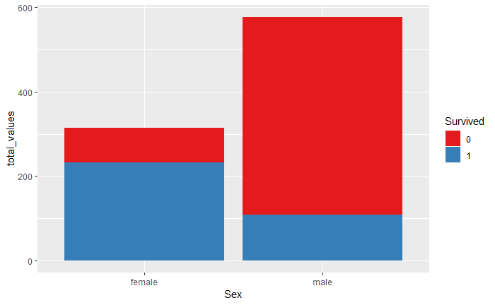

**Gender and class**  
Men were less likely to survive the sinking of the Titanic but were they more likely to travel in lower classes?

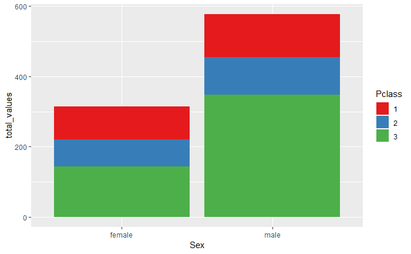

**Age of Passengers**  
There are 177 passengers for whom their Age is not recorded.

| PassengerId | Survived | Pclass | Name | Sex | Age | SibSp | Parch | Ticket | Fare | Cabin | Embarked |
| --- | --- | --- | --- | --- | --- | --- | --- | --- | --- | --- | --- |
| 6 | 0 | 3 | Moran, Mr. James | male | NA | 0 | 0 | 330877 | 8.4583 |  | Q |
| 18 | 1 | 2 | Williams, Mr. Charles Eugene | male | NA | 0 | 0 | 244373 | 13.0000 |  | S |
| 20 | 1 | 3 | Masselmani, Mrs. Fatima | female | NA | 0 | 0 | 2649 | 7.2250 |  | C |
| 27 | 0 | 3 | Emir, Mr. Farred Chehab | male | NA | 0 | 0 | 2631 | 7.2250 |  | C |
| 29 | 1 | 3 | O'Dwyer, Miss. Ellen "Nellie" | female | NA | 0 | 0 | 330959 | 7.8792 |  | Q |
| 30 | 0 | 3 | Todoroff, Mr. Lalio | male | NA | 0 | 0 | 349216 | 7.8958 |  | S |
| 32 | 1 | 1 | Spencer, Mrs. William Augustus (Marie Eugenie) | female | NA | 1 | 0 | PC 17569 | 146.5208 | B78 | C |
| 33 | 1 | 3 | Glynn, Miss. Mary Agatha | female | NA | 0 | 0 | 335677 | 7.7500 |  | Q |
| 37 | 1 | 3 | Mamee, Mr. Hanna | male | NA | 0 | 0 | 2677 | 7.2292 |  | C |
| 43 | 0 | 3 | Kraeff, Mr. Theodor | male | NA | 0 | 0 | 349253 | 7.8958 |  | C |

[output cut: 167 more lines]

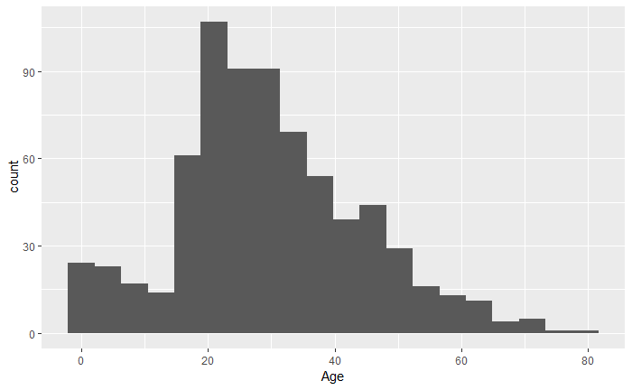

Some passengers have an age less than 1 but these seem to be legitimate values. The data reveals what appear to be 9 month old twins, who both survived.

| Name | Age | Survived |
| --- | --- | --- |
| Caldwell, Master. Alden Gates | 0.83 | 1 |
| Allison, Master. Hudson Trevor | 0.92 | 1 |
| Baclini, Miss. Helene Barbara | 0.75 | 1 |
| Baclini, Miss. Eugenie | 0.75 | 1 |
| Hamalainen, Master. Viljo | 0.67 | 1 |
| Thomas, Master. Assad Alexander | 0.42 | 1 |
| Richards, Master. George Sibley | 0.83 | 1 |

**Port of Embarkation**  
Port of embarkation shows most passengers boarded the boat at Southampton. Those that boarded in Cherbourg appear to show a higher survival rate than passengers boarding at either Southampton or Queenstown.  
There also appears to be a small number of passengers whose embarkation point is not known.

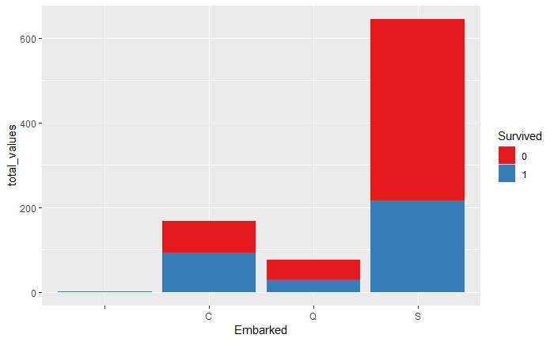

**Passenger Names**  
No names are duplicated in the original dataset.

| Name | total_values |
| --- | --- |

The title used by passengers can be broken out of the Name field.

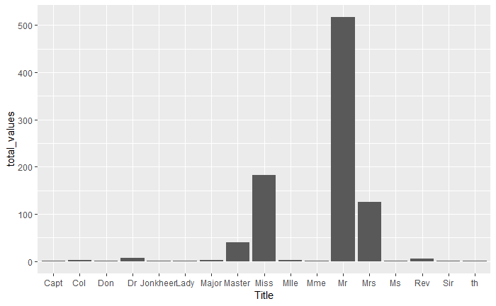